# Biostat 203B Homework 5

Due Mar 22 @ 11:59PM

Author

Lingyi Zhang and 606332255

Display my machine memory.

```r
memuse::Sys.meminfo()
```

```
Totalram:    8.000 GiB
Freeram:   801.703 MiB
```

## Predicting ICU duration

Using the ICU cohort `mimiciv_icu_cohort.rds` you built in Homework 4, develop at least three machine learning approaches (logistic regression with enet regularization, random forest, boosting, SVM, MLP, etc) plus a model stacking approach for predicting whether a patient’s ICU stay will be longer than 2 days. You should use the `los_long` variable as the outcome. You algorithms can use patient demographic information (gender, age at ICU `intime`, marital status, race), ICU admission information (first care unit), the last lab measurements before the ICU stay, and first vital measurements during ICU stay as features. You are welcome to use any feature engineering techniques you think are appropriate; but make sure to not use features that are not available at an ICU stay’s `intime`. For instance, `last_careunit` cannot be used in your algorithms.

1. Data preprocessing and feature engineering.
2. Partition data into 50% training set and 50% test set. Stratify partitioning according to `los_long`. For grading purpose, sort the data by `subject_id`, `hadm_id`, and `stay_id` and use the seed `203` for the initial data split. Below is the sample code.

Import pakcages:

```r
library(tidymodels)
library(dplyr)
library(tidyverse)
library(caret)
library(ROSE)
library(mice)
library(fastDummies)
library(lubridate)
library(randomForest)
library(e1071)
library(xgboost)
library(ROCR)
library(caret)
library(shapr)
library(kableExtra)
```

```r
set.seed(203) # random seed

# read rds data
mimiciv_icu_cohort <- readRDS('mimic_icu_cohort.rds')$inputs$data

# sort
mimiciv_icu_cohort <- mimiciv_icu_cohort |>
  arrange(subject_id, hadm_id, stay_id)
```

### Feature engineering

#### select columns with useful data

```r
##### Feature engineering
str(mimiciv_icu_cohort)
```

```
tibble [73,181 × 41] (S3: tbl_df/tbl/data.frame)
 $ subject_id                           : int [1:73181] 10000032 10000980 10001217 10001217 10001725 10001884 10002013 10002155 10002155 10002155 ...
 $ hadm_id                              : int [1:73181] 29079034 26913865 24597018 27703517 25563031 26184834 23581541 20345487 23822395 28994087 ...
 $ stay_id                              : int [1:73181] 39553978 39765666 37067082 34592300 31205490 37510196 39060235 32358465 33685454 31090461 ...
 $ first_careunit                       : Factor w/ 7 levels "Cardiac Vascular Intensive Care Unit (CVICU)",..: 3 3 5 5 4 3 1 3 2 4 ...
 $ last_careunit                        : Factor w/ 7 levels "Cardiac Vascular Intensive Care Unit (CVICU)",..: 3 3 5 5 4 3 1 3 2 4 ...
 $ intime                               : POSIXct[1:73181], format: "2180-07-23 14:00:00" "2189-06-27 08:42:00" ...
 $ outtime                              : POSIXct[1:73181], format: "2180-07-23 23:50:47" "2189-06-27 20:38:27" ...
 $ los                                  : num [1:73181] 0.41 0.498 1.118 0.948 1.339 ...
 $ admittime                            : POSIXct[1:73181], format: "2180-07-23 12:35:00" "2189-06-27 07:38:00" ...
 $ dischtime                            : POSIXct[1:73181], format: "2180-07-25 17:55:00" "2189-07-03 03:00:00" ...
 $ deathtime                            : POSIXct[1:73181], format: NA NA ...
 $ admission_type                       : Factor w/ 5 levels "EW EMER.","OBSERVATION ADMIT",..: 1 1 1 5 1 2 3 1 1 1 ...
 $ admit_provider_id                    : chr [1:73181] "P30KEH" "P30KEH" "P4645A" "P99698" ...
 $ admission_location                   : Factor w/ 4 levels "EMERGENCY ROOM",..: 1 1 1 2 4 1 2 1 4 1 ...
```

[output cut: 27 more lines]

```r
# Transform Type
numeric_vars <- c("creatinine", "potassium", "sodium", "chloride", "bicarbonate",
                  "hematocrit", "white_blood_cell_count", "glucose",
                  "heartrate", "systolic_non_invasive_blood_pressure",
                  "diastolic_non_invasive_blood_pressure", "temperature_Fahrenheit",
                  "respiratory_rate")
mimiciv_icu_cohort[numeric_vars] <- lapply(mimiciv_icu_cohort[numeric_vars], function(x) as.numeric(as.character(x)))
# check NA
na_counts <- mimiciv_icu_cohort %>%
  summarise(across(everything(), ~sum(is.na(.))))
print(width=Inf, na_counts)
```

```
# A tibble: 1 × 41
  subject_id hadm_id stay_id first_careunit last_careunit intime outtime   los
       <int>   <int>   <int>          <int>         <int>  <int>   <int> <int>
1          0       0       0              0             0      0       0     0
  admittime dischtime deathtime admission_type admit_provider_id
      <int>     <int>     <int>          <int>             <int>
1         0         0     64860              0                 2
  admission_location discharge_location insurance language marital_status  race
               <int>              <int>     <int>    <int>          <int> <int>
1                  0                637         0        0           5113     0
  edregtime edouttime hospital_expire_flag gender anchor_age anchor_year
      <int>     <int>                <int>  <int>      <int>       <int>
1     24898     24898                    0      0          0           0
  anchor_year_group   dod creatinine potassium sodium chloride bicarbonate
              <int> <int>      <int>     <int>  <int>    <int>       <int>
1                 0 44907      18457     24888  27662    18274       19508
  hematocrit white_blood_cell_count glucose heartrate
       <int>                  <int>   <int>     <int>
1      18002                  18973   67459     14102
  systolic_non_invasive_blood_pressure diastolic_non_invasive_blood_pressure
                                 <int>                                 <int>
1                                20509                                 20492
  temperature_Fahrenheit respiratory_rate los_long
                   <int>            <int>    <int>
1                  57197            14921        0
```

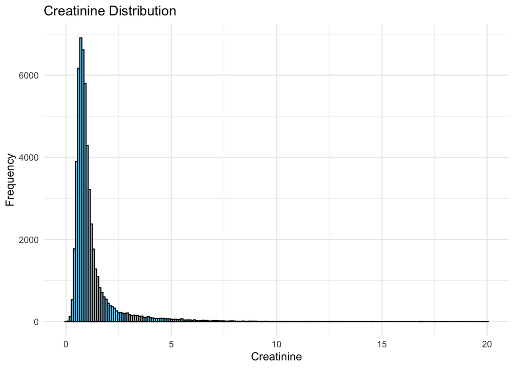

```r
# select useful cols
# no glucose potassium sodium because too much data is missing.
cols <- c("intime","outtime","los","admittime","dischtime","admission_type","insurance","language","marital_status","race","hospital_expire_flag","gender",
"anchor_age","anchor_year","creatinine","chloride", "bicarbonate","hematocrit", "white_blood_cell_count","heartrate", "systolic_non_invasive_blood_pressure", "diastolic_non_invasive_blood_pressure", "temperature_Fahrenheit", "respiratory_rate","los_long")

mimiciv_icu_cohort <- mimiciv_icu_cohort %>% select(all_of(cols))

# see data distribution(other is the same)
ggplot(mimiciv_icu_cohort, aes(x = creatinine)) +
  geom_histogram(binwidth = 0.1, fill = "skyblue", color = "black") +
  theme_minimal() +
  ggtitle("Creatinine Distribution") +
  xlab("Creatinine") +
  ylab("Frequency")
```

#### Deal with time, Calculate the time difference

```r
mimiciv_icu_cohort <- mimiciv_icu_cohort %>%
  mutate(
    los_minutes = as.numeric(difftime(outtime, intime, units = "mins")),
    process_minutes = as.numeric(difftime(dischtime, admittime, units = "mins"))
  ) %>%
  select(-intime, -outtime, -admittime, -dischtime)
```

#### impute data with NA

```r
imputed_data <- mimiciv_icu_cohort
# Deal with NA use Multiple interpolation
continuous_vars <- select_if(imputed_data, is.numeric)
categorical_vars <- select_if(imputed_data, function(x) is.factor(x) | is.character(x))
# Continuous variables: Fill missing values with the median
for (var in names(continuous_vars)) {
  imputed_data[[var]] <- ifelse(is.na(imputed_data[[var]]),
                      median(imputed_data[[var]], na.rm = TRUE),
                      imputed_data[[var]])
}
# Categorical variable: Fill missing values with mode
for (var in names(categorical_vars)) {
  mode_value <- names(sort(table(imputed_data[[var]]), decreasing = TRUE))[1]
  imputed_data[[var]] <- ifelse(is.na(imputed_data[[var]]),
                      as.character(mode_value),
                      imputed_data[[var]])
}
# check NA
na_counts <- imputed_data %>%
  summarise(across(everything(), ~sum(is.na(.))))
print(width=Inf, na_counts)
```

```
# A tibble: 1 × 23
    los admission_type insurance language marital_status  race
  <int>          <int>     <int>    <int>          <int> <int>
1     0              0         0        0              0     0
  hospital_expire_flag gender anchor_age anchor_year creatinine chloride
                 <int>  <int>      <int>       <int>      <int>    <int>
1                    0      0          0           0          0        0
  bicarbonate hematocrit white_blood_cell_count heartrate
        <int>      <int>                  <int>     <int>
1           0          0                      0         0
  systolic_non_invasive_blood_pressure diastolic_non_invasive_blood_pressure
                                 <int>                                 <int>
1                                    0                                     0
  temperature_Fahrenheit respiratory_rate los_long los_minutes process_minutes
                   <int>            <int>    <int>       <int>           <int>
1                      0                0        0           0               0
```

```r
str(imputed_data)
```

```
tibble [73,181 × 23] (S3: tbl_df/tbl/data.frame)
 $ los                                  : num [1:73181] 0.41 0.498 1.118 0.948 1.339 ...
 $ admission_type                       : int [1:73181] 1 1 1 5 1 2 3 1 1 1 ...
 $ insurance                            : chr [1:73181] "Medicaid" "Medicare" "Other" "Other" ...
 $ language                             : chr [1:73181] "ENGLISH" "ENGLISH" "?" "?" ...
 $ marital_status                       : chr [1:73181] "WIDOWED" "MARRIED" "MARRIED" "MARRIED" ...
 $ race                                 : chr [1:73181] "WHITE" "BLACK" "WHITE" "WHITE" ...
 $ hospital_expire_flag                 : int [1:73181] 0 0 0 0 0 1 0 1 0 0 ...
 $ gender                               : chr [1:73181] "F" "F" "F" "F" ...
 $ anchor_age                           : int [1:73181] 52 73 55 55 46 68 53 80 80 80 ...
 $ anchor_year                          : int [1:73181] 2180 2186 2157 2157 2110 2122 2156 2128 2128 2128 ...
 $ creatinine                           : num [1:73181] 0.4 2.2 0.9 0.4 0.9 0.6 1.1 1.5 0.9 0.9 ...
 $ chloride                             : num [1:73181] 97 108 102 103 100 97 97 88 102 102 ...
 $ bicarbonate                          : num [1:73181] 27 24 26 27 32 37 29 25 26 26 ...
 $ hematocrit                           : num [1:73181] 32.1 23.6 30.8 38.5 34 22.9 30.5 25.4 30.8 30.8 ...
 $ white_blood_cell_count               : num [1:73181] 4.8 4.8 8.6 8.8 11.1 13.4 11.7 7.1 8.6 8.6 ...
 $ heartrate                            : num [1:73181] 94 69 83 80 73 74 94 75 106 83 ...
 $ systolic_non_invasive_blood_pressure : num [1:73181] 85 131 121 107 91 86 106 121 138 121 ...
 $ diastolic_non_invasive_blood_pressure: num [1:73181] 59 69 66 78 58 48 60 66 66 66 ...
 $ temperature_Fahrenheit               : num [1:73181] 98.2 98.2 99.1 98.2 98.2 98.2 98.2 98.2 98.5 97.8 ...
 $ respiratory_rate                     : num [1:73181] 20 21 20 22 23 14 14 16 16 20 ...
 $ los_long                             : logi [1:73181] FALSE FALSE FALSE FALSE FALSE TRUE ...
 $ los_minutes                          : num [1:73181] 591 716 1610 1365 1928 ...
 $ process_minutes                      : num [1:73181] 3200 8362 9784 8517 4312 ...
```

#### Preprocess data

```r
# Normalization Min-max
num_vars <- c("los", "anchor_age","anchor_year","creatinine", "chloride", "bicarbonate", "hematocrit", "white_blood_cell_count", "heartrate","systolic_non_invasive_blood_pressure","diastolic_non_invasive_blood_pressure","temperature_Fahrenheit","respiratory_rate","los_minutes","process_minutes")
data_norm <- imputed_data %>%
  mutate_at(vars(num_vars), ~(. - min(.)) / (max(.) - min(.)))
# one-hot
data_onehot <- fastDummies::dummy_cols(data_norm, select_columns = c("admission_type","language","insurance", "marital_status", "race", "hospital_expire_flag","gender"),remove_selected_columns=TRUE)
```

#### Split data to train and test

```r
data_split <- initial_split(
  data_onehot,
  strata = "los_long",
  prop = 0.5
  )

train_set <- training(data_split)
train_set$los_long <- as.factor(train_set$los_long)
test_set <- testing(data_split)
test_set$los_long <- as.factor(test_set$los_long)
```

3. Train and tune the models using the training set. ### Training Models and test #### Random Forest Train

```r
rf_train_st <- Sys.time()

# train
train_x <- train_set %>% select(-los_long)
train_y <- train_set$los_long
rf_model <- randomForest(x = train_x, y = train_y, ntree = 100)

rf_train_et <- Sys.time()

rf_train_time <- rf_train_et - rf_train_st

cat("Random Forest Train Time Usage: ", rf_train_time, "\n")
```

```
Random Forest Train Time Usage:  3.978711
```

#### Random Forest Test

```r
test_x <- test_set %>% select(-los_long)
test_y <- test_set$los_long
rf_pred <- predict(rf_model, newdata = test_x, type = "response")
rf_pred_prob <- predict(rf_model, newdata = test_x, type = "prob")

pred <- prediction(predictions = rf_pred_prob[,2], labels = test_y)
perf <- performance(pred, "auc")
rf_auc <- perf@y.values[[1]]
cat("Random Forest Area Under ROC Curve (AUC): ", rf_auc, "\n")
```

```
Random Forest Area Under ROC Curve (AUC):  1
```

```r
rf_accuracy <- mean(rf_pred == test_y)
cat("Random Forest Accuracy: ", rf_accuracy, "\n")
```

```
Random Forest Accuracy:  1
```

#### Support Vector Machine (SVM)

```r
svm_train_st <- Sys.time()

svm_model <- svm(los_long ~ ., data = train_set, kernel = "radial",probability = TRUE)

svm_train_et <- Sys.time()

svm_train_time = svm_train_et - svm_train_st
cat("SVM Train Time Usage: ", svm_train_time, "\n")
```

```
SVM Train Time Usage:  3.430899
```

```r
svm_pred_prob <- predict(svm_model, newdata = test_x, probability = TRUE)
svm_pred_classes <- predict(svm_model, newdata = test_x, probability = FALSE)
svm_pred_classes <- as.numeric(svm_pred_classes) -1
svm_pred_probabilities <- attr(svm_pred_prob, "probabilities")[,2]

pred <- prediction(svm_pred_probabilities, test_y)
perf <- performance(pred, measure = "auc")
svm_auc <- as.numeric(perf@y.values)
cat("SVM Area Under ROC Curve (AUC): ", svm_auc, "\n")
```

```
SVM Area Under ROC Curve (AUC):  0.9967098
```

```r
svm_accuracy <- mean(svm_pred_classes == test_y)
cat("SVM Accuracy: ", svm_accuracy, "\n")
```

```
SVM Accuracy:  0
```

#### Boosting

```r
train_y <- as.numeric(train_set$los_long) - 1
train_x <- as.matrix(train_set[, !names(train_set) %in% "los_long"])

test_y <- as.numeric(test_set$los_long) - 1
test_x <- as.matrix(test_set[, !names(test_set) %in% "los_long"])

dtrain <- xgb.DMatrix(data = train_x, label = train_y)
dtest <- xgb.DMatrix(data = test_x, label = test_y)
num_class <- length(levels(factor(train_set$los_long)))

params <- list(
  objective = "binary:logistic",
  eval_metric = "logloss",
  max_depth = 6,
  eta = 0.3
)

boost_train_st <- Sys.time()

xgb_model <- xgboost(
  params = params,
  data = dtrain,
  nrounds = 100,
  verbose = 0,
  nthread = 2,
  early_stopping_rounds = 10,
)

boost_train_et <- Sys.time()

boost_train_time <-  boost_train_et - boost_train_st
cat("Boosting Train Time Usage: ", boost_train_time, "\n")
```

```
Boosting Train Time Usage:  0.7003
```

```r
preds <- predict(xgb_model, dtest)
pred <- prediction(preds, test_y)

perf <- performance(pred, "auc")
boost_auc <- as.numeric(perf@y.values)

predicted_classes <- ifelse(preds > 0.5, 1, 0)
conf_matrix <- confusionMatrix(factor(predicted_classes), factor(test_y))
boost_accuracy <- conf_matrix$overall['Accuracy']

cat("Boosting Area Under ROC Curve (AUC):", boost_auc, "\n")
```

```
Boosting Area Under ROC Curve (AUC): 1
```

```r
cat("Boosting Accuracy:", boost_accuracy, "\n")
```

```
Boosting Accuracy: 1
```

4. Compare model classification performance on the test set. Report both the area under ROC curve and accuracy for each machine learning algorithm and the model stacking. Interpret the results. What are the most important features in predicting long ICU stays? How do the models compare in terms of performance and interpretability?

### Performance

```r
rf_train_time <- as.numeric(rf_train_time)
svm_train_time <- as.numeric(svm_train_time)
boost_train_time <- as.numeric(boost_train_time)

model_data <- data.frame(
  Model = c("Boost", "SVM", "Random Forest"),
  Accuracy = c(boost_accuracy, svm_accuracy, rf_accuracy),
  AUC = c(boost_auc, svm_auc, rf_auc),
  TrainTime = c(boost_train_time, svm_train_time, rf_train_time)
)

kable(model_data, caption = "Model Performance and Training Time Comparison", align = 'c')
```

Model Performance and Training Time Comparison

| Model | Accuracy | AUC | TrainTime |
| --- | --- | --- | --- |
| Boost | 1 | 1.0000000 | 0.700300 |
| SVM | 0 | 0.9967098 | 3.430899 |
| Random Forest | 1 | 1.0000000 | 3.978711 |

#### View feature contributions using random forest

```r
importance(rf_model)
```

```
                                      MeanDecreaseGini
los                                       8043.2266987
anchor_age                                  20.4745101
anchor_year                                 12.5024764
creatinine                                  17.6031144
chloride                                    27.8827127
bicarbonate                                 16.8361364
hematocrit                                  67.9945427
white_blood_cell_count                      31.0702610
heartrate                                   18.2119322
systolic_non_invasive_blood_pressure        19.5546929
diastolic_non_invasive_blood_pressure       16.6498575
temperature_Fahrenheit                       5.5799063
respiratory_rate                            33.4322945
los_minutes                               8824.8208627
process_minutes                           1007.8430563
admission_type_1                             3.9648256
admission_type_2                             3.8772991
admission_type_3                             4.2954459
admission_type_4                             9.5370028
admission_type_5                             1.4797798
language_?                                   1.7517257
language_ENGLISH                             1.1293186
insurance_Medicaid                           1.3830932
insurance_Medicare                           2.5268264
insurance_Other                              2.3226951
marital_status_DIVORCED                      1.5766672
marital_status_MARRIED                       1.6820546
marital_status_SINGLE                        1.5107630
marital_status_WIDOWED                       1.3394318
race_ASIAN                                   0.9930695
race_BLACK                                   1.1268944
race_HISPANIC                                0.8855285
race_Other                                   2.9020606
race_WHITE                                   1.9817731
hospital_expire_flag_0                      19.8255388
hospital_expire_flag_1                      29.9381617
gender_F                                     1.6454424
gender_M                                     1.8976458
```

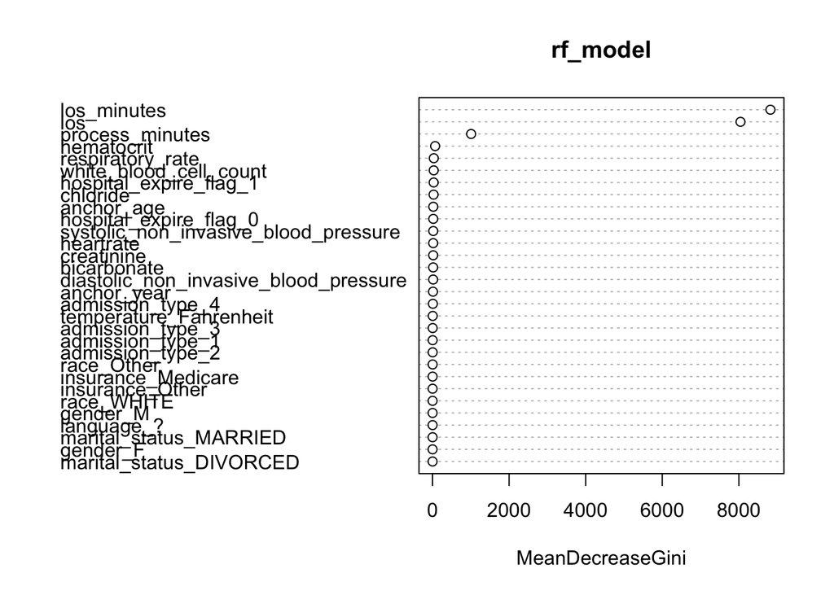

```r
varImpPlot(rf_model)
```

- The most important three features for predicting long-term ICU stay are los_minutes, los, and process_minutes. Los_minutes and process_minutes are calculated through feature engineering based on the difference in hospital discharge times, and they have a strong correlation with the label.
- For Model interpretability: Random Forest and tree-based Boost models are relatively good in terms of interpretability, as they can provide intuitive information about feature importance.
- SVM models may be slightly less interpretable, especially when using non-linear kernel functions, because their decision boundaries are difficult to intuitively understand in high-dimensional space.